# Section 5 Analysis

## section 6.4.4: water points with some households outside of village (30%)

```r
# Calculate share of water points with outside households
hh_outside_share <- pm_survey %>%
  dplyr::filter(wp_category %in% c("DSW Footprint", "DSW Expansion", "DSW in ILC village", "ILC")) %>%
  dplyr::filter(!(country == "UGANDA" & wp_category == "ILC")) %>%
  group_by(country, wp_category) %>%
  summarise(
    n_water_points = n(),
    wp_with_outside_hh = sum(hh_outside == TRUE, na.rm = TRUE),
    share_wp_with_outside = round(wp_with_outside_hh / n_water_points * 100, 1),
    .groups = "drop"
  )

print(hh_outside_share)
```

```
## # A tibble: 6 × 5
##   country wp_category        n_water_points wp_with_outside_hh share_wp_with_outside
##   <chr>   <chr>                       <int>              <int>                 <dbl>
## 1 MALAWI  DSW Expansion                  59                 16                  27.1
## 2 MALAWI  DSW Footprint                  46                 22                  47.8
## 3 MALAWI  DSW in ILC village             43                 11                  25.6
## 4 MALAWI  ILC                            45                  5                  11.1
## 5 UGANDA  DSW Expansion                  74                 18                  24.3
## 6 UGANDA  DSW Footprint                  34                 17                  50
```

```r
# Overall share across all water points
overall_share <- pm_survey %>%
  dplyr::filter(wp_category %in% c("DSW Footprint", "DSW Expansion", "DSW in ILC village", "ILC")) %>%
  dplyr::filter(!(country == "UGANDA" & wp_category == "ILC")) %>%
  summarise(
    total_water_points = n(),
    total_wp_with_outside = sum(hh_outside == TRUE, na.rm = TRUE),
    overall_share_wp_with_outside = round(total_wp_with_outside / total_water_points * 100, 1)
  )

print(overall_share)
```

```
## # A tibble: 1 × 3
##   total_water_points total_wp_with_outside overall_share_wp_with_outside
##                <int>                 <int>                         <dbl>
## 1                301                    89                          29.6
```

# section 6.4.5 double-counting: how many hh ids come up more than once? [numbers are currently off - updated in description below, but not in report]

```r
appearing_twice_households <- pm_survey_households_clean %>%
  count(household_id, name = "times_appeared") %>%
  dplyr::filter(times_appeared > 1) %>%
  summarize(
    appearing_twice_households = n_distinct(household_id)
  )

appearing_twice_households
```

| appearing_twice_households |
| --- |
| 627 |

```r
double_counted_households <- pm_survey_households_clean %>%
  count(household_id, name = "times_appeared") %>%
  dplyr::filter(times_appeared > 1) %>%
  left_join(hh_census %>% select(household_id, wp_secweek), by = "household_id") %>%
  dplyr::filter(wp_secweek == FALSE) %>%# limit to HHs that say they only use 1 water point
  summarize(
    double_counted_households = n_distinct(household_id)
  )

double_counted_households
```

| double_counted_households |
| --- |
| 332 |

## section 6.4.6 regression of chlorination on being listed by promoter

I regress chlorination on household presence in the promoter lists, limiting the sample to households using water points in the promoter survey. We find a significant positive association between these for both Uganda and Malawi.

```r
hh_survey <- hh_survey %>%
  mutate(
    listed_by_promoter = ifelse(household_id %in% pm_survey_households$household_id, 1, 0)
  )

promoter_wp_households <- hh_survey %>%
  dplyr::filter(promoter_survey == 1)

uganda_promoter_wp <- promoter_wp_households %>%
  dplyr::filter(country == "UGANDA")

malawi_promoter_wp <- promoter_wp_households %>%
  dplyr::filter(country == "MALAWI")

uganda_model <- lm(disctcr ~ listed_by_promoter, data = uganda_promoter_wp)
malawi_model <- lm(disctcr ~ listed_by_promoter, data = malawi_promoter_wp)

stargazer(uganda_model, malawi_model,
          type = "text",
          title = "Association between Being Listed by Promoter and Chlorination",
          dep.var.labels = "DISCTCR",
          covariate.labels = c("Listed by Promoter"),
          column.labels = c("Uganda", "Malawi"),
          model.numbers = FALSE,
          keep.stat = c("n", "rsq", "adj.rsq"))
```

```
##
## Association between Being Listed by Promoter and Chlorination
## ===============================================
##                        Dependent variable:
##                    ----------------------------
##                              DISCTCR
##                        Uganda        Malawi
## -----------------------------------------------
## Listed by Promoter    0.128**       0.113***
##                       (0.061)        (0.034)
##
## Constant              0.346***      0.137***
##                       (0.051)        (0.031)
##
## -----------------------------------------------
## Observations           1,013          1,935
## R2                     0.004          0.006
## Adjusted R2            0.003          0.005
## ===============================================
## Note:               *p<0.1; **p<0.05; ***p<0.01
```

## FCR instead of TCR

table 8 with FCR instead of TCR

```r
# column 1: household count and SE
hh_count_tbl <- pm_survey  %>%
  mutate(hh_listed = as.numeric(hh_listed)) %>%
  group_by(country, wp_category) %>%
  summarise(
    avg_hh_count = mean(hh_listed, na.rm = TRUE),
    wp_values = list(hh_listed[!is.na(hh_listed)]),
    .groups = "drop"
  ) %>%
  rowwise() %>%
  mutate(
    K = length(wp_values),
    between_var = if(K > 1) sum((wp_values - avg_hh_count)^2) / (K * (K - 1)) else 0,
    within_var = 0,
    total_var = between_var + within_var,
    se_hh_count = sqrt(total_var)
  ) %>%
  select(country, wp_category, avg_hh_count, se_hh_count)

# column 2: hh size and SE
hh_size_tbl <- hh_survey %>%
  dplyr::filter(survey == "Monitoring Survey") %>%
  group_by(country, wp_category, wp_id) %>%
  summarise(
    hh_size = mean(hh_members, na.rm = TRUE),
    .groups = "drop"
  ) %>%
  group_by(country, wp_category) %>%
  summarise(
    avg_hh_size = mean(hh_size, na.rm = TRUE),
    wp_hh_sizes = list(hh_size[!is.na(hh_size)]),
    .groups = "drop"
  ) %>%
  rowwise() %>%
  mutate(
    K = length(wp_hh_sizes),
    between_var = if(K > 1) sum((wp_hh_sizes - avg_hh_size)^2) / (K * (K - 1)) else 0,
    within_var = 0,
    total_var = between_var + within_var,
    se_hh_size = sqrt(total_var)
  ) %>%
  select(country, wp_category, avg_hh_size, se_hh_size)

# column 6: chlorination rate
chl_tbl <- hh_survey %>%
  dplyr::filter(survey == "Monitoring Survey") %>%
  group_by(country, wp_category, wp_id) %>%
  summarise(
    wp_chl_rate = mean(discfcr > 0.2, na.rm = TRUE),
    wp_se_chl_rate = sqrt(wp_chl_rate * (1 - wp_chl_rate) / n()), # SE for proportion within WP
    .groups = "drop"
  ) %>%
  group_by(country, wp_category) %>%
  summarise(
    chl_rate = mean(wp_chl_rate, na.rm = TRUE),
    # store individual water point rates and SEs
    wp_rates = list(wp_chl_rate[!is.na(wp_chl_rate)]),
    wp_ses = list(wp_se_chl_rate[!is.na(wp_se_chl_rate)]),
    .groups = "drop"
  ) %>%
  # calculate SE using variance decomposition
  rowwise() %>%
  mutate(
    K = length(wp_rates),
    between_var = if(K > 1) sum((wp_rates - chl_rate)^2) / (K * (K - 1)) else 0,
    within_var = if(K > 0) sum(wp_ses^2) / (K^2) else 0,
    total_var = between_var + within_var,
    se_chl_rate = sqrt(total_var)
  ) %>%
  select(country, wp_category, chl_rate, se_chl_rate)

# merge + calculations (for columns 3, 5, and CI for column 6)
table8_fcr <- hh_count_tbl %>%
  left_join(hh_size_tbl, by = c("country", "wp_category")) %>%
  left_join(chl_tbl, by = c("country", "wp_category")) %>%
  left_join(country_totals, by = c("country", "wp_category")) %>%
  mutate(
    # column 3
    indiv_access_sample = avg_hh_count * avg_hh_size,
    # column 5
    indiv_access_popn = indiv_access_sample * country_total,
    # column 3 SE (delta method assuming covariance = 0)
    se_indiv_access_sample = sqrt(
      (avg_hh_size^2) * (se_hh_count^2) +
      (avg_hh_count^2) * (se_hh_size^2)
    ),
    # column 5 SE (variable multiplied by a constant)
    se_indiv_access_popn = country_total * se_indiv_access_sample,
    # column 5 95% confidence interval
    ci_lower_indiv_access_popn = indiv_access_popn - 1.96 * se_indiv_access_popn,
    ci_upper_indiv_access_popn = indiv_access_popn + 1.96 * se_indiv_access_popn,
     # column 6 95% confidence interval
    ci_lower_chl_rate = chl_rate - 1.96 * se_chl_rate,
    ci_upper_chl_rate = chl_rate + 1.96 * se_chl_rate
  ) %>%
  mutate(
    across(c(avg_hh_count, avg_hh_size, indiv_access_sample, indiv_access_popn,
         se_hh_count, se_hh_size,
         se_indiv_access_sample, se_indiv_access_popn, ci_lower_indiv_access_popn,
         ci_upper_indiv_access_popn),
       ~ round(.x, 2))
  ) %>%
  select(
  country, wp_category, avg_hh_count, se_hh_count, avg_hh_size, se_hh_size, indiv_access_sample, se_indiv_access_sample,
  country_total, indiv_access_popn,  se_indiv_access_popn, # se_indiv_access_popn is not used directly in table 8, but is needed for CI calculation below
  ci_lower_indiv_access_popn, ci_upper_indiv_access_popn, chl_rate, ci_lower_chl_rate, ci_upper_chl_rate
  ) %>%
  # presentation settings
  dplyr::filter(wp_category %in% c("DSW Footprint", "DSW Expansion", "DSW in ILC village", "ILC")) %>%
  dplyr::filter(!(country == "UGANDA" & wp_category == "ILC"))  %>%
  mutate(country = factor(country,
                           levels = c("UGANDA", "MALAWI"))) %>%
  mutate(wp_category = factor(wp_category,
                           levels = c("DSW Footprint", "DSW Expansion", "DSW in ILC village", "ILC"))) %>%
  arrange(country, wp_category)

table8_fcr %>%
  ungroup() %>%
  kable(format = "html") %>%
  kable_styling(
    bootstrap_options = c("striped", "hover", "condensed"),
    full_width = TRUE,
    font_size = 9
  ) %>%
  scroll_box(width = "100%")
```

| country | wp_category | avg_hh_count | se_hh_count | avg_hh_size | se_hh_size | indiv_access_sample | se_indiv_access_sample | country_total | indiv_access_popn | se_indiv_access_popn | ci_lower_indiv_access_popn | ci_upper_indiv_access_popn | chl_rate | ci_lower_chl_rate | ci_upper_chl_rate |
| --- | --- | --- | --- | --- | --- | --- | --- | --- | --- | --- | --- | --- | --- | --- | --- |
| UGANDA | DSW Footprint | 48.85 | 4.03 | 5.88 | 0.43 | 287.36 | 31.58 | 4606 | 1323570.1 | 145465.81 | 1038457.2 | 1608683.1 | 0.3134409 | 0.1760247 | 0.4508570 |
| UGANDA | DSW Expansion | 31.97 | 1.95 | 6.21 | 0.24 | 198.50 | 14.28 | 12528 | 2486863.3 | 178867.90 | 2136282.2 | 2837444.4 | 0.3274892 | 0.2444690 | 0.4105094 |
| MALAWI | DSW Footprint | 46.52 | 4.14 | 4.58 | 0.24 | 213.20 | 21.90 | 3123 | 665831.4 | 68408.43 | 531750.8 | 799911.9 | 0.3142857 | 0.1907369 | 0.4378345 |
| MALAWI | DSW Expansion | 37.37 | 2.45 | 4.84 | 0.13 | 180.80 | 12.81 | 12040 | 2176826.1 | 154177.51 | 1874638.2 | 2479014.0 | 0.2491228 | 0.1601403 | 0.3381053 |
| MALAWI | DSW in ILC village | 41.16 | 4.39 | 4.34 | 0.17 | 178.55 | 20.36 | 1035 | 184797.2 | 21071.28 | 143497.5 | 226096.9 | 0.2412281 | 0.1292806 | 0.3531755 |
| MALAWI | ILC | 21.84 | 1.56 | 4.21 | 0.19 | 92.02 | 7.74 | 2376 | 218634.9 | 18400.44 | 182570.1 | 254699.8 | 0.1521605 | 0.0667007 | 0.2376203 |

```r
# country totals and CIs
country_totals_table8_fcr <- table8_fcr %>%
  group_by(country) %>%
  summarise(
    total_indiv_access_popn = sum(indiv_access_popn, na.rm = TRUE),
    # SE: square root of sum of squared SEs (assuming independence)
    se_total_indiv_access_popn = sqrt(sum(se_indiv_access_popn^2, na.rm = TRUE)),
    .groups = "drop"
  ) %>%
  # confidence interval
  mutate(
    # for total access
    ci_lower_total_access = total_indiv_access_popn - 1.96 * se_total_indiv_access_popn,
    ci_upper_total_access = total_indiv_access_popn + 1.96 * se_total_indiv_access_popn,
  ) %>%
  select(
    country,
    total_indiv_access_popn,
    ci_lower_total_access, ci_upper_total_access
  )

country_totals_table8_fcr
```

| country | total_indiv_access_popn | ci_lower_total_access | ci_upper_total_access |
| --- | --- | --- | --- |
| UGANDA | 3810433 | 3358552 | 4262314 |
| MALAWI | 3246090 | 2910975 | 3581204 |

table 10 with FCR instead of TCR

```r
# column 1: household count and SE
hh_count_tbl_wp_census <- hh_census %>%
  dplyr::filter(wp_id %in% pm_survey$wp_id) %>%
  group_by(country, wp_category, wp_id) %>%
  summarise(
    hh_count = n_distinct(household_id),   # number of households per wp
    .groups = "drop"
  ) %>%
  group_by(country, wp_category) %>%
  summarise(
    avg_hh_count = mean(hh_count, na.rm = TRUE),
    wp_values = list(hh_count[!is.na(hh_count)]), # used in calculating SE below
    .groups = "drop"
  ) %>%
  rowwise() %>%
  # calculating SE
  mutate(
    K = length(wp_values),
    between_var = if(K > 1) sum((wp_values - avg_hh_count)^2) / (K * (K - 1)) else 0,
    within_var = 0,
    total_var = between_var + within_var,
    se_hh_count = sqrt(total_var)
  ) %>%
  select(country, wp_category, avg_hh_count, se_hh_count)

# column 2: household size and SE
hh_size_tbl_wp_census <- hh_survey %>%
  dplyr::filter(survey == "Household Survey") %>%
  dplyr::filter(wp_id %in% pm_survey$wp_id) %>%
  group_by(country, wp_category, wp_id) %>%
  summarise(
    hh_size = mean(hh_members, na.rm = TRUE),
    .groups = "drop"
  ) %>%
  group_by(country, wp_category) %>%
  summarise(
    avg_hh_size = mean(hh_size, na.rm = TRUE),
    wp_hh_sizes = list(hh_size[!is.na(hh_size)]), # used in SE calculations below
    .groups = "drop"
  ) %>%
  rowwise() %>%
  # calculating SE
  mutate(
    K = length(wp_hh_sizes),
    between_var = if(K > 1) sum((wp_hh_sizes - avg_hh_size)^2) / (K * (K - 1)) else 0,
    within_var = 0,
    total_var = between_var + within_var,
    se_hh_size = sqrt(total_var)
  ) %>%
  select(country, wp_category, avg_hh_size, se_hh_size)

# column 6: chlorination rate
chl_tbl_wp_census <- hh_survey %>%
  dplyr::filter(survey == "Household Survey") %>%
  dplyr::filter(wp_id %in% pm_survey$wp_id) %>%
  group_by(country, wp_category, wp_id) %>%
  summarise(
    wp_chl_rate = mean(discfcr > 0.2, na.rm = TRUE),
    wp_se_chl_rate = sqrt(wp_chl_rate * (1 - wp_chl_rate) / n()), # SE for proportion within WP
    .groups = "drop"
  ) %>%
  group_by(country, wp_category) %>%
  summarise(
    chl_rate = mean(wp_chl_rate, na.rm = TRUE),
    # store individual water point rates and SEs
    wp_rates = list(wp_chl_rate[!is.na(wp_chl_rate)]),
    wp_ses = list(wp_se_chl_rate[!is.na(wp_se_chl_rate)]),
    .groups = "drop"
  ) %>%
  # calculating SE
  rowwise() %>%
  mutate(
    K = length(wp_rates),
    between_var = if(K > 1) sum((wp_rates - chl_rate)^2) / (K * (K - 1)) else 0,
    within_var = if(K > 0) sum(wp_ses^2) / (K^2) else 0,
    total_var = between_var + within_var,
    se_chl_rate = sqrt(total_var)
  ) %>%
  select(country, wp_category, chl_rate, se_chl_rate)

# merge + calculations
table10_fcr <- hh_count_tbl_wp_census %>%
  left_join(hh_size_tbl_wp_census, by = c("country", "wp_category")) %>%
  left_join(chl_tbl_wp_census, by = c("country", "wp_category")) %>%
  left_join(country_totals, by = c("country", "wp_category")) %>% # this is created in the "table 8" chunk
  mutate(
    # column 3
    indiv_access_sample = avg_hh_count * avg_hh_size,
    # column 5
    indiv_access_popn = indiv_access_sample * country_total,
    # column 3 SE (delta method assuming covariance = 0)
    se_indiv_access_sample = sqrt(
      (avg_hh_size^2) * (se_hh_count^2) +
      (avg_hh_count^2) * (se_hh_size^2)
    ),
    # column 5 SE (variable multiplied by a constant)
    se_indiv_access_popn = country_total * se_indiv_access_sample,
    # column 5 95% confidence interval
    ci_lower_indiv_access_popn = indiv_access_popn - 1.96 * se_indiv_access_popn,
    ci_upper_indiv_access_popn = indiv_access_popn + 1.96 * se_indiv_access_popn,
     # column 6 95% confidence interval
    ci_lower_chl_rate = chl_rate - 1.96 * se_chl_rate,
    ci_upper_chl_rate = chl_rate + 1.96 * se_chl_rate
  ) %>%
  # rounding
  mutate(
    across(c(avg_hh_count, avg_hh_size, indiv_access_sample, indiv_access_popn, se_hh_count, se_hh_size,
         se_indiv_access_sample, se_indiv_access_popn, ci_lower_indiv_access_popn, ci_upper_indiv_access_popn),
       ~ round(.x, 2))
  ) %>%
  select(
  country, wp_category, avg_hh_count, se_hh_count, avg_hh_size, se_hh_size, indiv_access_sample, se_indiv_access_sample,
  country_total, indiv_access_popn,  se_indiv_access_popn, # se_indiv_access_popn is not used directly in table 8, but is needed for CI calculation below
  ci_lower_indiv_access_popn, ci_upper_indiv_access_popn, chl_rate, ci_lower_chl_rate, ci_upper_chl_rate
  ) %>%
  # presentation settings
  dplyr::filter(wp_category %in% c("DSW Footprint", "DSW Expansion", "DSW in ILC village", "ILC")) %>%
  dplyr::filter(!(country == "UGANDA" & wp_category == "ILC"))  %>%
  mutate(country = factor(country,
                           levels = c("UGANDA", "MALAWI"))) %>%
  mutate(wp_category = factor(wp_category,
                           levels = c("DSW Footprint", "DSW Expansion", "DSW in ILC village", "ILC"))) %>%
  arrange(country, wp_category)

table10_fcr %>%
  ungroup() %>%
  kable(format = "html") %>%
  kable_styling(
    bootstrap_options = c("striped", "hover", "condensed"),
    full_width = TRUE,
    font_size = 9
  ) %>%
  scroll_box(width = "100%")
```

| country | wp_category | avg_hh_count | se_hh_count | avg_hh_size | se_hh_size | indiv_access_sample | se_indiv_access_sample | country_total | indiv_access_popn | se_indiv_access_popn | ci_lower_indiv_access_popn | ci_upper_indiv_access_popn | chl_rate | ci_lower_chl_rate | ci_upper_chl_rate |
| --- | --- | --- | --- | --- | --- | --- | --- | --- | --- | --- | --- | --- | --- | --- | --- |
| UGANDA | DSW Footprint | 38.06 | 4.84 | 5.60 | 0.17 | 212.96 | 27.85 | 4606 | 980889.8 | 128262.25 | 729495.8 | 1232283.8 | 0.2439664 | 0.1520159 | 0.3359169 |
| UGANDA | DSW Expansion | 37.16 | 3.00 | 5.60 | 0.21 | 207.97 | 18.44 | 12528 | 2605439.2 | 231066.41 | 2152549.0 | 3058329.3 | 0.2147956 | 0.1382416 | 0.2913496 |
| MALAWI | DSW Footprint | 29.30 | 3.24 | 4.49 | 0.12 | 131.63 | 14.97 | 3123 | 411081.1 | 46764.16 | 319423.3 | 502738.8 | 0.1948922 | 0.1289203 | 0.2608641 |
| MALAWI | DSW Expansion | 28.78 | 2.21 | 4.69 | 0.15 | 135.04 | 11.17 | 12040 | 1625868.3 | 134467.42 | 1362312.2 | 1889424.5 | 0.1903748 | 0.1155624 | 0.2651873 |
| MALAWI | DSW in ILC village | 31.17 | 3.66 | 4.36 | 0.13 | 135.80 | 16.49 | 1035 | 140551.9 | 17066.23 | 107102.1 | 174001.7 | 0.1863924 | 0.0972296 | 0.2755553 |
| MALAWI | ILC | 16.42 | 1.66 | 4.63 | 0.18 | 76.05 | 8.27 | 2376 | 180695.2 | 19642.58 | 142195.7 | 219194.6 | 0.1299000 | 0.0543879 | 0.2054121 |

```r
country_totals_table10_fcr <- table10_fcr %>%
  group_by(country) %>%
  summarise(
    total_indiv_access_popn = sum(indiv_access_popn, na.rm = TRUE),
    # SE: square root of sum of squared SEs (assuming independence)
    se_total_indiv_access_popn = sqrt(sum(se_indiv_access_popn^2, na.rm = TRUE)),
    .groups = "drop"
  ) %>%
  # confidence interval
  mutate(
    ci_lower_total_access = total_indiv_access_popn - 1.96 * se_total_indiv_access_popn,
    ci_upper_total_access = total_indiv_access_popn + 1.96 * se_total_indiv_access_popn,
  ) %>%
  select(
    country,
    total_indiv_access_popn,
    ci_lower_total_access, ci_upper_total_access
  )
country_totals_table10_fcr
```

| country | total_indiv_access_popn | ci_lower_total_access | ci_upper_total_access |
| --- | --- | --- | --- |
| UGANDA | 3586329 | 3068344 | 4104314 |
| MALAWI | 2358196 | 2074535 | 2641858 |

# differences in HH size - difference in means test

```r
comparison <- table8 %>%
  select(country, wp_category, avg_hh_size_table8 = avg_hh_size, se_hh_size_table8 = se_hh_size) %>%
  left_join(
    table10 %>% select(country, wp_category, avg_hh_size_table10 = avg_hh_size, se_hh_size_table10 = se_hh_size),
    by = c("country", "wp_category")
  ) %>%
  mutate(
    diff = avg_hh_size_table8 - avg_hh_size_table10,
    se_diff = sqrt(se_hh_size_table8^2 + se_hh_size_table10^2),
    z_stat = diff / se_diff,
    p_value = 2 * pnorm(-abs(z_stat)),
    significant = p_value < 0.05
  ) %>%
  select(country, wp_category,
         avg_hh_size_table8, avg_hh_size_table10, diff,
         se_diff, z_stat, p_value, significant)

comparison %>%
  kable(digits = 4) %>%
  kable_styling()
```

| country | wp_category | avg_hh_size_table8 | avg_hh_size_table10 | diff | se_diff | z_stat | p_value | significant |
| --- | --- | --- | --- | --- | --- | --- | --- | --- |
| UGANDA | DSW Footprint | 5.88 | 5.60 | 0.28 | 0.4624 | 0.6056 | 0.5448 | FALSE |
| UGANDA | DSW Expansion | 6.21 | 5.60 | 0.61 | 0.3189 | 1.9128 | 0.0558 | FALSE |
| MALAWI | DSW Footprint | 4.58 | 4.49 | 0.09 | 0.2683 | 0.3354 | 0.7373 | FALSE |
| MALAWI | DSW Expansion | 4.84 | 4.69 | 0.15 | 0.1985 | 0.7557 | 0.4498 | FALSE |
| MALAWI | DSW in ILC village | 4.34 | 4.36 | -0.02 | 0.2140 | -0.0935 | 0.9255 | FALSE |
| MALAWI | ILC | 4.21 | 4.63 | -0.42 | 0.2617 | -1.6047 | 0.1086 | FALSE |

# diff in chlorination

```r
hh_survey_filtered <- hh_survey %>%
  dplyr::filter(wp_category %in% c("DSW Expansion", "DSW Footprint")) %>%
  dplyr::filter(survey == "Monitoring Survey") %>%
  dplyr::filter(wp_id %in% pm_survey$wp_id) %>%
  # First aggregate to water point level
  group_by(country, wp_category, wp_id, village_id) %>%
  summarise(
    wp_chl_rate = mean(disctcr > 0.2, na.rm = TRUE),
    .groups = "drop"
  ) %>%
  mutate(expansion_dummy = ifelse(wp_category == "DSW Expansion", 1, 0))

# Uganda regression - use regular lm
uganda_data <- hh_survey_filtered %>% filter(country == "UGANDA")
uganda_reg_lm <- lm(wp_chl_rate ~ expansion_dummy, data = uganda_data)

# Malawi regression - use regular lm
malawi_data <- hh_survey_filtered %>% filter(country == "MALAWI")
malawi_reg_lm <- lm(wp_chl_rate ~ expansion_dummy, data = malawi_data)

# Get cluster-robust standard errors using lm_robust for reference
uganda_reg_robust <- lm_robust(wp_chl_rate ~ expansion_dummy,
                               data = uganda_data,
                               clusters = village_id,
                               se_type = "CR2")

malawi_reg_robust <- lm_robust(wp_chl_rate ~ expansion_dummy,
                               data = malawi_data,
                               clusters = village_id,
                               se_type = "CR2")

# Extract cluster-robust SEs
uganda_se <- uganda_reg_robust$std.error
malawi_se <- malawi_reg_robust$std.error

# Use stargazer with custom SEs
library(stargazer)
stargazer(uganda_reg_lm, malawi_reg_lm,
          type = "text",
          se = list(uganda_se, malawi_se),
          title = "Chlorination Regressions by Country",
          column.labels = c("Uganda", "Malawi"),
          covariate.labels = c("DSW Expansion (vs. Footprint)"),
          dep.var.labels = "Chlorination Level (disctcr)",
          keep.stat = c("n", "rsq"),
          star.cutoffs = c(0.05, 0.01, 0.001),
          notes = "Standard errors clustered at village level in parentheses")
```

```
##
## Chlorination Regressions by Country
## ========================================================================================
##                                                  Dependent variable:
##                               ----------------------------------------------------------
##                                              Chlorination Level (disctcr)
##                                           Uganda                       Malawi
##                                            (1)                           (2)
## ----------------------------------------------------------------------------------------
## DSW Expansion (vs. Footprint)             -0.070                       -0.069
##                                          (0.091)                       (0.064)
##
## Constant                                 0.530***                     0.345***
##                                          (0.077)                       (0.035)
##
## ----------------------------------------------------------------------------------------
## Observations                                94                           90
## R2                                        0.008                         0.012
## ========================================================================================
## Note:                                                      *p<0.05; **p<0.01; ***p<0.001
##                                Standard errors clustered at village level in parentheses
```

```r
hh_survey_chlorine <- hh_survey %>%
  dplyr::filter(survey == "Household Survey") %>%
  mutate(
    chlorination = ifelse(disctcr > 0.2, 1, 0)  # Create binary indicator for each household
  )

# Run regression with cluster-robust standard errors
library(estimatr)
regression_model_robust <- lm_robust(
  chlorination ~ hh_members,
  data = hh_survey_chlorine,
  clusters = village_id,
  se_type = "CR2"
)

# For stargazer, run regular lm and extract clustered SEs
regression_model <- lm(disctcr ~ hh_members, data = hh_survey_chlorine)

# Extract cluster-robust SEs from lm_robust
# clustered_se <- regression_model_robust$std.error

# Use stargazer with clustered SEs
stargazer(regression_model,
          type = "text",
          # se = list(clustered_se),
          title = "Household Size and Chlorination",
          dep.var.labels = "Chlorination (TCR > 0.2)",
          covariate.labels = c("HH members"),
          keep.stat = c("n", "rsq", "adj.rsq", "f"),
          notes = "Standard errors clustered at village level in parentheses")
```

```
##
## Household Size and Chlorination
## ======================================================================
##                                 Dependent variable:
##              ---------------------------------------------------------
##                              Chlorination (TCR > 0.2)
## ----------------------------------------------------------------------
## HH members                            0.010**
##                                       (0.005)
##
## Constant                             0.177***
##                                       (0.027)
##
## ----------------------------------------------------------------------
## Observations                           2,815
## R2                                     0.001
## Adjusted R2                            0.001
## F Statistic                   4.090** (df = 1; 2813)
## ======================================================================
## Note:                                      *p<0.1; **p<0.05; ***p<0.01
##              Standard errors clustered at village level in parentheses
```

## exploratory - not directly referenced in report:

number of villages in pm_survey and wp_census: all villages are in the pm_survey

```r
# total number of villages in the promoter survey
vil_count_pm <- pm_survey %>%
  group_by(country) %>%
  summarise(
    n_vil_pm_survey = n_distinct(village_id),
    .groups = "drop"
  )

print(vil_count_pm)
```

```
## # A tibble: 3 × 2
##   country n_vil_pm_survey
##   <chr>             <int>
## 1 MALAWI              100
## 2 UGANDA               56
## 3 <NA>                 17
```

```r
# total number of villages in the wp census
vil_count_wp <- wp_census %>%
  group_by(country) %>%
  summarise(
    n_vil_wp_census = n_distinct(village_id),
    .groups = "drop"
  )

print(vil_count_wp)
```

```
## # A tibble: 2 × 2
##   country n_vil_wp_census
##   <chr>             <int>
## 1 MALAWI              100
## 2 UGANDA               56
```

association between hh_listed by promoter and hh_count in hh census - it is positive and significant for all country-wp_category combos

```r
hh_counts_summary <- hh_census %>%
  group_by(wp_id) %>%
  summarise(
    hh_counts_hhcensus = n_distinct(household_id),
    .groups = "drop"
  )

comparison <- pm_survey %>%
  dplyr::filter(country == "MALAWI" & wp_category == "ILC") %>% # change around country and wp_category to analyze different subsamples
  select(wp_id, hh_listed, cal_hh_count) %>%
  mutate(
    hh_listed = as.numeric(hh_listed),
    cal_hh_count = as.numeric(cal_hh_count)
  ) %>%
  left_join(hh_counts_summary, by = "wp_id") %>%
  arrange(wp_id)

regression_model <- lm(hh_counts_hhcensus ~ hh_listed, data = comparison)

stargazer(regression_model,
          type = "text",
          title = "Uganda Footprint: Association between Promoter-Listed HH and Census HH Count",
          dep.var.labels = "HH Count (Census)",
          covariate.labels = c("HH Listed (Promoter)"),
          keep.stat = c("n", "rsq", "adj.rsq", "f"))
```

```
##
## Uganda Footprint: Association between Promoter-Listed HH and Census HH Count
## ================================================
##                          Dependent variable:
##                      ---------------------------
##                           HH Count (Census)
## ------------------------------------------------
## HH Listed (Promoter)          0.462***
##                                (0.147)
##
## Constant                        5.937
##                                (3.668)
##
## ------------------------------------------------
## Observations                     40
## R2                              0.205
## Adjusted R2                     0.185
## F Statistic             9.824*** (df = 1; 38)
## ================================================
## Note:                *p<0.1; **p<0.05; ***p<0.01
```

overlap between promoter list and household census

```r
unique_pm_survey <- unique(pm_survey_households_clean$household_id)
unique_hh_census <- unique(hh_census$household_id)

overlap_count <- length(intersect(unique_pm_survey, unique_hh_census))

cat("Unique household_ids in pm_survey_households_clean:", length(unique_pm_survey), "\n")
```

```
## Unique household_ids in pm_survey_households_clean: 9083
```

```r
cat("Unique household_ids in hh_census:", length(unique_hh_census), "\n")
```

```
## Unique household_ids in hh_census: 20142
```

```r
cat("Household_ids present in both datasets:", overlap_count, "\n")
```

```
## Household_ids present in both datasets: 7814
```

```r
cat("Percentage of PM survey households also in census:",
    round(overlap_count / length(unique_pm_survey) * 100, 1), "%\n")
```

```
## Percentage of PM survey households also in census: 86 %
```

number of water points used per household - households in HH census

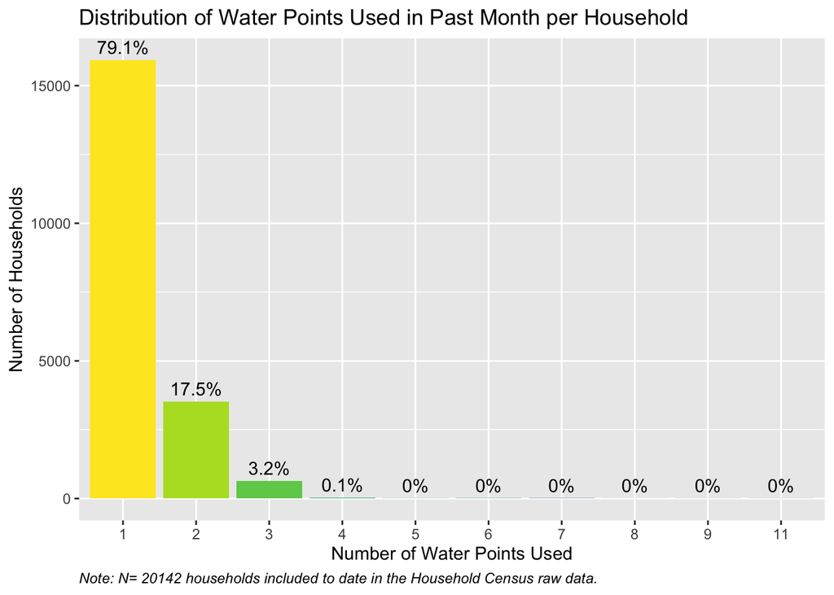

```r
# number of water points used per household - households in HH census
wp_distribution_census <-
  hh_census %>%
  mutate(total_wp_used = if_else(is.na(wp_secweekno), 1L, wp_secweekno + 1L)) %>%
  count(total_wp_used) %>%
  mutate(
    percentage = round(n / sum(n) * 100, 1),
    label = paste0(percentage, "%")
  )

# sample
total_households_census <- length(unique(trimws(as.character(hh_census$household_id))))

# plot
ggplot(wp_distribution_census, aes(x = as.factor(total_wp_used), y = n, fill = as.factor(total_wp_used))) +
  geom_col() +
  geom_text(
    aes(label = label),
    vjust = -0.5,
    color = "black"
  ) +
  scale_fill_viridis_d(option = "D", direction = -1, name = "Water Points Used") +
  labs(
    title = "Distribution of Water Points Used in Past Month per Household",
    x = "Number of Water Points Used",
    y = "Number of Households",
    caption = paste0("Note: N= ",total_households_census," households included to date in the Household Census raw data.")) +
  # theme +
  theme(
    plot.caption = element_text(hjust = 0, face = "italic"),
    legend.position = "none"
  )
```

number of water points used per household - households in promoter lists

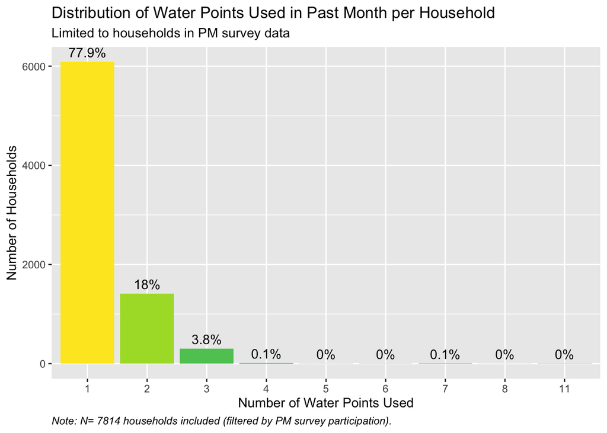

```r
# number of water points used per household - households in promoter lists
hh_census_filtered <- hh_census %>%
  dplyr::filter(household_id %in% pm_survey_households_clean$household_id)

wp_distribution_census <-
  hh_census_filtered %>%
  mutate(total_wp_used = if_else(is.na(wp_secweekno), 1L, wp_secweekno + 1L)) %>%
  count(total_wp_used) %>%
  mutate(
    percentage = round(n / sum(n) * 100, 1),
    label = paste0(percentage, "%")
  )

# sample
total_households_census <- length(unique(trimws(as.character(hh_census_filtered$household_id))))

# plot
ggplot(wp_distribution_census, aes(x = as.factor(total_wp_used), y = n, fill = as.factor(total_wp_used))) +
  geom_col() +
  geom_text(
    aes(label = label),
    vjust = -0.5,
    color = "black"
  ) +
  scale_fill_viridis_d(option = "D", direction = -1, name = "Water Points Used") +
  labs(
    title = "Distribution of Water Points Used in Past Month per Household",
    subtitle = "Limited to households in PM survey data",
    x = "Number of Water Points Used",
    y = "Number of Households",
    caption = paste0("Note: N= ",total_households_census," households included (filtered by PM survey participation).")) +
  # theme +
  theme(
    plot.caption = element_text(hjust = 0, face = "italic"),
    legend.position = "none"
  )
```